# Installation of TheSNPpit on Singularity

## Requirements and Problems

From the documenatation given in the user [guide](https://tsp-repo.thesnppit.net/resources/TheSNPpit-user-guide-latest.pdf), it is clear that TheSNPpit (TSP), as it comes out of the box, is a program that is targetted towards running on a single machine and is not constructed for a distributed setup. This means that there is one instance of the database-server and one installation of the client programs that accesses the data in the database. Different users on the same machine can use the client programs which can all interact with the given instance of the database on the same machine.

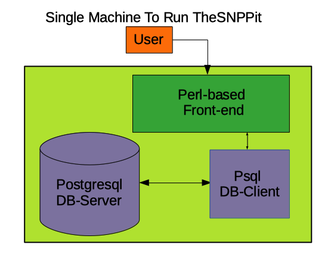

It gets more complicated if we want to be able work with the same data from different machines. This requires to get access to the database-server from different clients running on different machines. This requires a distributed setup over different machines.

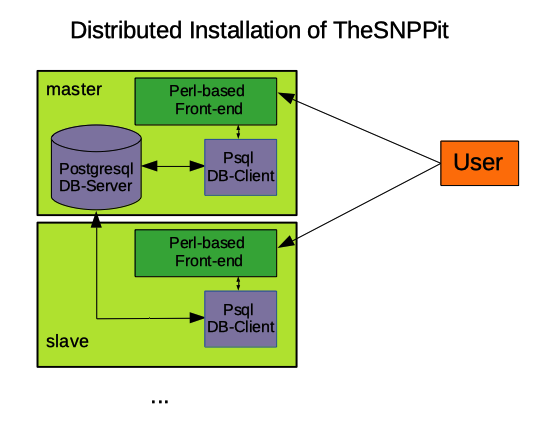

A further requirement for using the provided installation infrastructure is that root access is available on the machine where TSP is to be installed. In most High-Performance-Computing (HPC) environments, this requirement is not met. On an HPC-machine every user has a login account with restricted permissions. For the zws-servers at Qualitas AG, all users access the servers via the common account `zws` which does not have root-priviledges. Hence, with respect to the installation of TSP, we are in an HPC-scenario.

As a consequence of the above described points, the automatic installation script given in the tarball from TSP cannot be used. In what follows, strategies for solving the above mentioned problems are developed and described.

## Strategy

Different strategies to solve the above described problems can be envisaged. The different strategies are characterized by different levels of complexity and offer different functionalities. In summary the following strategies can be layed out.

1. Simple one machine installation of TSP. This solution has a low level of complexity, but it does offer the functionality of using TSP software from only one machine.
2. Distributed setup where TSP client software can be used from different machines. This solution corresponds to a distributed setup which is more complex but it does offer the functionality of using TSP software from different machines.

In a first step, the TSP system is installed following strategy 1. That means, the complete system is installed on a single machine. Together with the container based context of the zws-servers, the installation is done in a separate container image.

In what follows the manual installation procedure described in the guide of TSP is followed to produce a single-machine installation in a container image.

## Installation

### User Guide

The installation of TSP is described in Chapter 6 of the guide available at https://tsp-repo.thesnppit.net/resources/TheSNPpit-user-guide-latest.pdf. The general installation procedure consists of downloading and unpacking the tar-ball into the directory `/usr/local/TheSNPpit_current`. TSP is installed via the script `bin/install`. This installation requires root priviledges and hence cannot be used in an HPC-environment.

### Manual Installation

In section 6.3 of the user guide a manual procedure is described. In Listing 57, the software dependencies of TSP are described.

# Old Stuff Below

## Installation Resources

### User Guide

We are currently checking the user guide on https://tsp-repo.thesnppit.net/resources/TheSNPpit-user-guide-latest.pdf for hints on how to install. Chapter 6 of the user guide describes the installation. The proposed way to install TheSNPpit is to download the tar-ball from the website, to unpack the tarball and to run the script `bin/install`. Since this requires root priviledges, this cannot be used in a singularity container.

### Manual Installation

In section 6.3 of the user guide, a manual installation is described. In Listing 57, the software required by TheSNPpit is described. The installation procedure given there is based on system-wide installations.

## Experiments

This section describes the trials and experiments with a local installation. The experiments consist of the four steps given in section 6.3 of the user guide.

### System software installation

In a first experiment, the system software is added to the list of software that is installed in the singularity container. The following statement checks whether the required system software is already in the singularity definition file.

```bash
cd /home/quagadmin/simg/img/ubuntu1804lts
for p in perl gcc PostgreSQL PostgreSQL-contrib libecpg6 libecpg-dev libdbi-perl libinline-perl libmodern-perl-perl libcloog-ppl1 libcloog-ppl0 libfile-slurp-perl libdbd-pg-perl libjudy-dev
do
  echo " * Checking def for $p ..."
  grep "$p" ../../def/ubuntu1804lts/quagzws_ubuntu1804lts.def
  sleep 2
done
```

All packages that were indicated except for `perl` and `gcc` which are installed in the container by default are added to the container building definition file and a new image is built.

```bash
cd /home/quagadmin/simg/img/thesnppit
../../shub/bash/build_simg.sh -d ../../def/thesnppit/quagzws_ubuntu1804lts.def -w /home/quagadmin/simg/img/thesnppit
```

The original aim was to have all system software including the postgres database installed in the singularity container. But with such a database installation, user `zws` cannot start a local database, as is shown below

```
zws@1-htz:~$ /var/lib/postgresql/10/main/bin/initdb -D /qualstorzws01/data_projekte/projekte/thesnppit/data -A trust -U zws
bash: /var/lib/postgresql/10/main/bin/initdb: Permission denied
```

A first attempt to fix this problem is to change the directory permissions using `chmod` for `/var/lib/postgresql/10/main` in the singularity recipe file. This makes the directory visible, but the `bin` directory with the program to init a DB is not included there. According to https://superuser.com/questions/1320145/postgresql-10-does-not-start-under-ubuntu-18-04, the bin-directory is found in `/usr/lib/postgresql/10/bin`. Hence the command to init a DB is

```
SNPDATADIR=/qualstorzws01/data_projekte/projekte/thesnppit/data
if [ ! -d "$SNPDATADIR" ]; then mkdir -p $SNPDATADIR;fi
/usr/lib/postgresql/10/bin/initdb -D $SNPDATADIR -A trust -U zws
# The files belonging to this database system will be owned by user "zws".
# This user must also own the server process.
#
# The database cluster will be initialized with locale "en_US.UTF-8".
# The default database encoding has accordingly been set to "UTF8".
# The default text search configuration will be set to "english".
#
# Data page checksums are disabled.
#
# fixing permissions on existing directory /qualstorzws01/data_projekte/projekte/thesnppit/data ... ok
# creating subdirectories ... ok
# selecting default max_connections ... 100
# selecting default shared_buffers ... 128MB
# selecting dynamic shared memory implementation ... posix
# creating configuration files ... ok
# running bootstrap script ... ok
# performing post-bootstrap initialization ... ok
# syncing data to disk ... ok
#
# Success. You can now start the database server using:
#
#     /usr/lib/postgresql/10/bin/pg_ctl -D /qualstorzws01/data_projekte/projekte/thesnppit/data -l logfile start
```

This created several configuration files of which the port setting in postgresql.conf was changed.

```
cd $SNPDATADIR
mv postgresql.conf postgresql.conf.org
cat postgresql.conf.org | sed -e "s/\#port = 5432/port = 5434/" > postgresql.conf
rm postgresql.conf.org
```

The database server is then started with

```
LOGDIR=/qualstorzws01/data_projekte/projekte/thesnppit/log
LOGFILE=$LOGDIR/`date +"%Y%m%d%H%M%S"`_postgres.log
if [ ! -d "$LOGDIR" ];then mkdir -p $LOGDIR;fi
/usr/lib/postgresql/10/bin/pg_ctl -D $SNPDATADIR -l $LOGFILE start
waiting for server to start.... done
server started
```

On `niesen` we have the problem that the data-directory must be u+rwx, but all other groups should not have access to this directory. Hence we get an error as

```
$ /usr/lib/postgresql/10/bin/pg_ctl -D $SNPDATADIR -l $LOGFILE start
waiting for server to start.... stopped waiting
pg_ctl: could not start server
Examine the log output.
```

This problem cannot easily be solved, because, we cannot change permissions for a directory using `chmod`.

A solution is searched by searching for `postgresql start db with writable data directory` and reading some of the resulting links.

### Alternative Pseudo-local Storage of DB

Try to first put the DBDIR in a local volume and then move the whole story to the NAS

```
SNPDATADIR=/home/zws/thesnppit/pgdata
if [ ! -d "$SNPDATADIR" ]; then echo " * Create dir: $SNPDATADIR ...";mkdir -p $SNPDATADIR;fi
/usr/lib/postgresql/10/bin/initdb -D $SNPDATADIR -A trust -U zws
```

The following adjust of the postgresql db server config is not done anymore.

```
cd $SNPDATADIR
mv postgresql.conf postgresql.conf.org
cat postgresql.conf.org | sed -e "s/\#port = 5432/port = 5434/" > postgresql.conf
rm postgresql.conf.org
```

Test whether the db server can be started from here

```
LOGDIR=/home/zws/thesnppit/log
LOGFILE=$LOGDIR/`date +"%Y%m%d%H%M%S"`_postgres.log
if [ ! -d "$LOGDIR" ];then echo " * Create dir: $LOGDIR ...";mkdir -p $LOGDIR;fi
/usr/lib/postgresql/10/bin/pg_ctl -D $SNPDATADIR -l $LOGFILE start
```

This works. We can test whether the db-server runs with

```
/usr/lib/postgresql/10/bin/pg_isready -h localhost
# localhost:5432 - accepting connections
echo $?
# 0
```

Now we stop and move the content of `SNPDATADIR`.

```
/usr/lib/postgresql/10/bin/pg_ctl -D $SNPDATADIR stop
```

Moving the content of `SNPDATADIR`

```
NASSNPDATADIR=/qualstorzws01/data_projekte/projekte/thesnppit/pgdata
if [ ! -d "$NASSNPDATADIR" ];then echo " * Create dir: $NASSNPDATADIR ...";mkdir -p $NASSNPDATADIR;fi
cd $SNPDATADIR
ls -1 | while read f;do echo " * Moving $f ...";echo " * Linking $f";sleep 2;done
ls -1 | while read f;do echo " * Moving $f ...";mv $f $NASSNPDATADIR;echo " * Linking $f";ln -s $NASSNPDATADIR/$f $f;sleep 2;done
```

Try to start the db server again

```
LOGDIR=/home/zws/thesnppit/log
if [ ! -d "$LOGDIR" ];then echo " * Create dir: $LOGDIR ...";mkdir -p $LOGDIR;fi
LOGFILE=$LOGDIR/`date +"%Y%m%d%H%M%S"`_postgres.log
/usr/lib/postgresql/10/bin/pg_ctl -D $SNPDATADIR -l $LOGFILE start
```

According to the startup message and according to the logfile, this seams to work. The server is stopped to do a few cleanup tasks.

```
/usr/lib/postgresql/10/bin/pg_ctl -D $SNPDATADIR stop
```

### Installation and Configuration Cleanup

- This is no longer done: Move the unix socket from /var/run/postgresql to /home/zws/thesnppit/pgrun

```
PGRUN=/home/zws/thesnppit/pgrun
PGCONF=postgresql.conf
if [ ! -d "$PGRUN" ];then echo " * Create dir: $PGRUN ...";mkdir -p $PGRUN;chmod 777 $PGRUN;fi
cd $NASSNPDATADIR
mv $PGCONF $PGCONF.org
cat $PGCONF.org | sed -e "s|\#unix_socket_directories = '/var/run/postgresql'|unix_socket_directories = '$PGRUN'|" > $PGCONF
diff $PGCONF.org $PGCONF
```

- Move the data directory to data_tmp

```
TMPNASSNPDATADIR=/qualstorzws01/data_tmp/thesnppit/pgdata
if [ ! -d "$TMPNASSNPDATADIR" ];then echo " * Create dir: $TMPNASSNPDATADIR ...";mkdir -p $TMPNASSNPDATADIR;fi
cd $SNPDATADIR
#ls -1 | while read f
for f in base \
global \
pg_commit_ts \
pg_dynshmem \
pg_hba.conf \
pg_ident.conf \
pg_logical \
pg_multixact \
pg_notify \
pg_replslot \
pg_serial \
pg_snapshots \
pg_stat \
pg_stat_tmp \
pg_subtrans \
pg_tblspc \
pg_twophase \
PG_VERSION \
pg_wal \
pg_xact \
postgresql.auto.conf \
postgresql.conf \
postmaster.opts
do
  if [ -d "$NASSNPDATADIR/$f" ]
  then
    echo " * Copy dir $NASSNPDATADIR/$f to $TMPNASSNPDATADIR ..."
    cp -r $NASSNPDATADIR/$f  $TMPNASSNPDATADIR
  else
    echo " * Copy file $NASSNPDATADIR/$f to $TMPNASSNPDATADIR..."
    cp $NASSNPDATADIR/$f  $TMPNASSNPDATADIR
  fi
  echo " * Re-Linking $f"
  rm $f
  ln -s $TMPNASSNPDATADIR/$f $f
  sleep 2
done
```

Start the db-server with a different log file

```
LOGDIR=/qualstorzws01/data_tmp/thesnppit/log
if [ ! -d "$LOGDIR" ];then echo " * Create dir: $LOGDIR ...";mkdir -p $LOGDIR;fi
LOGFILE=$LOGDIR/`date +"%Y%m%d%H%M%S"`_postgres.log
/usr/lib/postgresql/10/bin/pg_ctl -D $SNPDATADIR -l $LOGFILE start
```

- This is no longer done: Move the unix socket from /home/zws/thesnppit/pgrun to /qualstorzws01/data_tmp/thesnppit/pgrun

```
OLDPGRUN=/home/zws/thesnppit/pgrun
PGRUN=/qualstorzws01/data_tmp/thesnppit/pgrun
PGCONF=postgresql.conf
if [ ! -d "$PGRUN" ];then echo " * Create dir: $PGRUN ...";mkdir -p $PGRUN;chmod 777 $PGRUN;fi
cd $TMPNASSNPDATADIR
mv $PGCONF $PGCONF.org
cat $PGCONF.org | sed -e "s|unix_socket_directories = '$OLDPGRUN'|unix_socket_directories = '$PGRUN'|" > $PGCONF
diff $PGCONF.org $PGCONF
```

```
LOGDIR=/qualstorzws01/data_tmp/thesnppit/pglog
if [ ! -d "$LOGDIR" ];then echo " * Create dir: $LOGDIR ...";mkdir -p $LOGDIR;fi
LOGFILE=$LOGDIR/`date +"%Y%m%d%H%M%S"`_postgres.log
/usr/lib/postgresql/10/bin/pg_ctl -D $SNPDATADIR -l $LOGFILE start
```

This seams to work.

The following stops the server again.

```
/usr/lib/postgresql/10/bin/pg_ctl -D $SNPDATADIR stop
```

## Client Connection

Try to get a connection using the client

```
# the local user zws already exists, hence there is not need for the following command
# /usr/lib/postgresql/10/bin/createuser -h localhost zws # throws an error and hence might not be necessary.
/usr/lib/postgresql/10/bin/createdb -h localhost -O zws zws
/usr/lib/postgresql/10/bin/psql -h localhost
```

First, we were able to connect to the db-server using psql as stated above. The basic functionalities according to http://postgresguide.com/utilities/psql.html worked from the client.

## Database Configuration

Different steps must be configured in the just installed database.

1. Add user snpadmin and hosts to pg_hba.conf. Because by default all users are allowed, we skip this

```
/usr/lib/postgresql/10/bin/pg_ctl -D $SNPDATADIR stop
cd $TMPNASSNPDATADIR
```

2. Create user snpadmin

```
/usr/lib/postgresql/10/bin/pg_ctl -D $SNPDATADIR -l $LOGFILE start
/usr/lib/postgresql/10/bin/createuser -h localhost -s postgres
/usr/lib/postgresql/10/bin/createuser -h localhost --superuser snpadmin
```

3. check whether DB was created

```
DB_NAME=TheSNPpit
/usr/lib/postgresql/10/bin/psql -l --tuples-only --quiet --no-align --field-separator=' '
/usr/lib/postgresql/10/bin/psql -l --tuples-only --quiet --no-align --field-separator=' ' | awk '{print $1}' | grep "^${DB_NAME}$"
```

4. drop the db

```
/usr/lib/postgresql/10/bin/dropdb $DB_NAME
```

## Install TheSNPPit Software

1. Start with downloading the tarball

```
cd;cd source
mkdir thesnppit
cd thesnppit/
wget --no-check-certificate https://tsp-repo.thesnppit.net/download/TheSNPpit-latest.tar.gz
tar -xvzf TheSNPpit-latest.tar.gz
cd TheSNPpit-1.1.4/
```

According to `doc/README.install` the download and the installation is directly done to /usr/local. For our case this procedure is modified slightly.

```
cd /qualstorzws01/data_projekte/linuxBin
wget --no-check-certificate https://tsp-repo.thesnppit.net/download/TheSNPpit-latest.tar.gz
tar -xvzf TheSNPpit-latest.tar.gz
rm TheSNPpit-latest.tar.gz
SNPPITVERSION=$(cat $(ls -1 TheSNPpit-*/etc/VERSION))
cd TheSNPpit-${SNPPITVERSION}/
```

The script `bin/INSTALL` was modified to `install_thesnppit.sh` by excluding all steps that cannot be applied in our environment. Once this installation is done, we can try to connect `thesnppit` with the database.

## First Experiments with a local PostgreSQL Database

### Local pgsql

In a first attempt, we try to compile our own pgsql database.

```bash
mkdir -p /home/zws/postgresql/9.5/main
cd source/postgres
wget https://ftp.postgresql.org/pub/source/v9.5.19/postgresql-9.5.19.tar.gz
tar -xvzf postgresql-9.5.19.tar.gz
cd postgresql-9.5.19/
./configure --prefix=/home/zws/postgresql/9.5/main
make
make install
```

According to https://stackoverflow.com/questions/40644400/create-postgresql-database-without-root-privilege, we try to start a local db-cluster using the following commands.

```bash
./postgresql/9.5/main/bin/initdb -D /home/zws/postgresql/9.5/main/data -A trust -U zws
```

The above resulted in the following output

```
The files belonging to this database system will be owned by user "zws".
This user must also own the server process.

The database cluster will be initialized with locale "en_US.UTF-8".
The default database encoding has accordingly been set to "UTF8".
The default text search configuration will be set to "english".

Data page checksums are disabled.

fixing permissions on existing directory /home/zws/postgresql/9.5/main/data ... ok
creating subdirectories ... ok
selecting default max_connections ... 100
selecting default shared_buffers ... 128MB
selecting default timezone ... Europe/Berlin
selecting dynamic shared memory implementation ... posix
creating configuration files ... ok
creating template1 database in /home/zws/postgresql/9.5/main/data/base/1 ... ok
initializing pg_authid ... ok
initializing dependencies ... ok
creating system views ... ok
loading system objects' descriptions ... ok
creating collations ... ok
creating conversions ... ok
creating dictionaries ... ok
setting privileges on built-in objects ... ok
creating information schema ... ok
loading PL/pgSQL server-side language ... ok
vacuuming database template1 ... ok
copying template1 to template0 ... ok
copying template1 to postgres ... ok
syncing data to disk ... ok

Success. You can now start the database server using:

    ./postgresql/9.5/main/bin/pg_ctl -D /home/zws/postgresql/9.5/main/data -l logfile start
```

The question about where the configuration is stored is answered by https://serverfault.com/questions/152942/location-of-postgresql-conf-and-pg-hba-conf-on-an-ubuntu-server

The above start command requires an empty `data` directory. The configuration files will all be placed into the data directory. In `postgresql.conf` the port was changed to 5434 to not get in conflict with any other running postgresql instances.

Connecting with the client to the running database required the following steps according to https://stackoverflow.com/questions/16973018/createuser-could-not-connect-to-database-postgres-fatal-role-tom-does-not-e/16974197#16974197

where the `createuser` statement threw an error at me, but the database creation worked. Afterwards I was able to connect with the client to the database.

```bash
./postgresql/9.5/main/bin/createuser -h localhost -p 5434 zws
./postgresql/9.5/main/bin/createdb -h localhost -p 5434 -O zws zws
./postgresql/9.5/main/bin/psql -h localhost -p 5434
```